# Coarse woody debris: Pre- and post-Tubbs fire

Morgan Gray

2022-11-09

## Overview

The aim of this research was to understand the impact of of the 2017 Tubbs fire on fuel loads. Our objective was to evaluate the impact of prescribed fire on fuel loads over time for five coarse woody debris fuel classes: 1-hr, 10-hr, 100-hr, 1000-hr rotten, and 1000-hr sound. To meet this objective, we compared the pre- and post-fire levels of these five lag-time fuel classes at nine long-term vegetation monitoring plots. Surveys were conducted at four time points: 2016 (1y pre-fire), 2017 (0y post-fire), 2019 (2y post-fire), and 2021 (4y post-fire). We conducted surveys along two transects per plot; each transect had one quadrat. Each time point had 18 data points: 9 plots x 2 transects x 1 quadrat.

Using the coarse woody debris data set as input, we asked the following questions:

1. Did the total fuel load (all fuel classes combined) differ between years?
2. Did fuel load differ between years by fuel class? If so, which years were different?

#### Fuel measurements for coarse woody debris mass

We answered these questions using a time series of plot-level data for (1) the total amount of coarse woody debris and (2) the mean amount of each of the five fuel classes. We defined “total (or all) coarse woody debris” as the combined total of the the five fuel classes within a plot: 1-hr, 10-hr, 100-hr, 1000-hr rotten, 1000-hr sound.

We calculated the *plot-level mean for each fuel class* to account for replicate surveys within each plot. To calculated the the *plot-level total* at each time point, we summed the plot means for all fuel classes by fuel type.

Below is a table that shows the plot-level mean at each time point for coarse woody debris (total and mean by fuel class).

| fuel_class | plot_id | 2016 | 2017 | 2019 | 2021 | metric | units |
| --- | --- | --- | --- | --- | --- | --- | --- |
| All | RxF01 | 13.410 | 114.207 | 111.788 | 21.150 | total | MT/ha |
| All | RxF02 | 16.327 | 1.684 | 2.693 | 1.475 | total | MT/ha |
| All | RxF03 | 11.540 | 14.906 | 15.052 | 38.496 | total | MT/ha |
| All | RxF04 | 39.361 | 0.824 | 7.817 | 16.135 | total | MT/ha |
| All | RxF05 | 10.690 | 0.094 | 0.336 | 10.725 | total | MT/ha |
| All | RxF06 | 47.333 | 8.666 | 12.473 | 4.054 | total | MT/ha |
| All | RxF07 | 44.831 | 56.827 | 33.710 | 49.655 | total | MT/ha |
| All | RxF08 | 18.282 | 64.982 | 35.324 | 4.599 | total | MT/ha |
| All | RxF09 | 15.773 | 0.060 | 0.209 | 4.048 | total | MT/ha |
| 1-hr | RxF01 | 1.091 | 0.284 | 0.716 | 0.165 | mean | MT/ha |
| 1-hr | RxF02 | 0.777 | 0.333 | 0.333 | 0.161 | mean | MT/ha |
| 1-hr | RxF03 | 0.605 | 0.133 | 0.310 | 0.015 | mean | MT/ha |
| 1-hr | RxF04 | 0.531 | 0.162 | 0.472 | 0.325 | mean | MT/ha |
| 1-hr | RxF05 | 0.525 | 0.094 | 0.336 | 0.332 | mean | MT/ha |
| 1-hr | RxF06 | 0.488 | 0.074 | 0.296 | 0.148 | mean | MT/ha |
| 1-hr | RxF07 | 0.415 | 0.458 | 0.591 | 0.147 | mean | MT/ha |
| 1-hr | RxF08 | 1.198 | 0.031 | 0.079 | 0.046 | mean | MT/ha |
| 1-hr | RxF09 | 1.024 | 0.060 | 0.209 | 0.136 | mean | MT/ha |
| 10-hr | RxF01 | 7.356 | 1.340 | 0.672 | 1.343 | mean | MT/ha |
| 10-hr | RxF02 | 6.692 | 1.351 | 2.361 | 1.314 | mean | MT/ha |
| 10-hr | RxF03 | 2.963 | 0.985 | 2.635 | 1.665 | mean | MT/ha |
| 10-hr | RxF04 | 3.305 | 0.661 | 1.321 | 0.992 | mean | MT/ha |
| 10-hr | RxF05 | 6.388 | 0.000 | 0.000 | 2.826 | mean | MT/ha |
| 10-hr | RxF06 | 7.286 | 0.000 | 2.314 | 0.000 | mean | MT/ha |
| 10-hr | RxF07 | 5.956 | 0.000 | 1.646 | 0.328 | mean | MT/ha |
| 10-hr | RxF08 | 6.195 | 0.000 | 0.000 | 0.659 | mean | MT/ha |
| 10-hr | RxF09 | 9.769 | 0.000 | 0.000 | 1.703 | mean | MT/ha |
| 100-hr | RxF01 | 4.963 | 0.000 | 0.000 | 0.000 | mean | MT/ha |
| 100-hr | RxF02 | 0.000 | 0.000 | 0.000 | 0.000 | mean | MT/ha |
| 100-hr | RxF03 | 0.000 | 1.649 | 1.649 | 0.000 | mean | MT/ha |
| 100-hr | RxF04 | 6.549 | 0.000 | 1.638 | 1.636 | mean | MT/ha |
| 100-hr | RxF05 | 1.743 | 0.000 | 0.000 | 1.743 | mean | MT/ha |
| 100-hr | RxF06 | 8.199 | 0.000 | 0.000 | 0.000 | mean | MT/ha |
| 100-hr | RxF07 | 9.882 | 0.000 | 1.625 | 0.000 | mean | MT/ha |
| 100-hr | RxF08 | 10.888 | 1.851 | 0.000 | 0.000 | mean | MT/ha |
| 100-hr | RxF09 | 4.980 | 0.000 | 0.000 | 0.000 | mean | MT/ha |
| 1000-hr rotten | RxF01 | 0.000 | 0.000 | 0.000 | 0.000 | mean | MT/ha |
| 1000-hr rotten | RxF02 | 0.000 | 0.000 | 0.000 | 0.000 | mean | MT/ha |
| 1000-hr rotten | RxF03 | 1.836 | 0.000 | 0.000 | 0.000 | mean | MT/ha |
| 1000-hr rotten | RxF04 | 28.976 | 0.000 | 0.000 | 0.000 | mean | MT/ha |
| 1000-hr rotten | RxF05 | 0.000 | 0.000 | 0.000 | 0.000 | mean | MT/ha |
| 1000-hr rotten | RxF06 | 6.275 | 0.000 | 0.000 | 0.000 | mean | MT/ha |
| 1000-hr rotten | RxF07 | 4.314 | 0.000 | 0.000 | 0.000 | mean | MT/ha |
| 1000-hr rotten | RxF08 | 0.000 | 0.000 | 0.000 | 0.000 | mean | MT/ha |
| 1000-hr rotten | RxF09 | 0.000 | 0.000 | 0.000 | 0.000 | mean | MT/ha |
| 1000-hr sound | RxF01 | 0.000 | 112.583 | 110.401 | 19.642 | mean | MT/ha |
| 1000-hr sound | RxF02 | 8.858 | 0.000 | 0.000 | 0.000 | mean | MT/ha |
| 1000-hr sound | RxF03 | 6.136 | 12.140 | 10.458 | 36.817 | mean | MT/ha |
| 1000-hr sound | RxF04 | 0.000 | 0.000 | 4.386 | 13.182 | mean | MT/ha |
| 1000-hr sound | RxF05 | 2.034 | 0.000 | 0.000 | 5.824 | mean | MT/ha |
| 1000-hr sound | RxF06 | 25.085 | 8.592 | 9.863 | 3.907 | mean | MT/ha |
| 1000-hr sound | RxF07 | 24.264 | 56.369 | 29.848 | 49.180 | mean | MT/ha |
| 1000-hr sound | RxF08 | 0.000 | 63.099 | 35.245 | 3.894 | mean | MT/ha |
| 1000-hr sound | RxF09 | 0.000 | 0.000 | 0.000 | 2.209 | mean | MT/ha |

#### Statistical methods

Statistically significant differences were identified using repeated measures analysis of variance (ANOVA) and post hoc comparisons. P-values were adjusted using the Bonferroni multiple testing correction method.

The repeated-measures ANOVA is used for analyzing data where same subjects are measured more than once. This test is also referred to as a within-subjects ANOVA or ANOVA with repeated measures. The “within-subjects” term means that the same individuals (here, individuals are plots) are measured on the same outcome variable under different time points. The main goal of a repeated measures ANOVA is to evaluate if there is a statistically significant interaction effect between within-subjects factors in explaining a continuous outcome variable. The repeated measures ANOVA makes the following assumptions about the data:

- No significant outliers in any cell of the design
- Normality: the outcome (or dependent) variable should be approximately normally distributed in each cell of the design
- Assumption of sphericity: the variance of the differences between groups should be equal

We assessed outliers using the the interquartile range (IQR; IQR = Q3 - Q1). Values above Q3 + 1.5xIQR or below Q1 - 1.5xIQR are considered as outliers. Values above Q3 + 3xIQR or below Q1 - 3xIQR are considered as extreme points (or extreme outliers). Q1 and Q3 are the first and third quartile, respectively. Extreme outliers can be due to data entry errors, measurement errors, or unusual values. The outlier may be included if one believes the result will not be substantially affected; this can be evaluated by comparing the result of the ANOVA with and without the outlier.

We assessed normality by visual inspection of a QQ plot for each time point. A QQ plot draws the correlation between a given data and the normal distribution. We also conducted the Shapiro-Wilk test for each time point. Using this method, normally distributed data will have p-value >0.05.

The assumption of sphericity was checked during the computation of the ANOVA test using the R function anova_test() [rstatix package]. The Mauchly’s test was internally used to assess the sphericity assumption, and the Greenhouse-Geisser sphericity correction was automatically applied to factors violating the sphericity assumption.

#### Check assumptions

##### *Check for outliers*

No extreme outliers were found for the total fuels subset.

There were nine extreme outliers in the mean by fuel class data set. Most outliers (n = 6) were from the year 2021. The 1-hr and 100-hr classes each had 4 outliers. We found the following extreme outliers by fuel class:

**1-hour**

- 2021 (RxF03, RxF04, RxF05, RxF08)

**100-hour**

- 2017 (RxF03, RxF08)
- 2021 (RxF04, RxF05)

**1000-hr rotten**

- excluded here because too many values are close to zero

**1000-hr sound**

| fuel_class | time | plot_id | si_value | is_outlier | is_extreme |
| --- | --- | --- | --- | --- | --- |
| hr0001 | 2021 | RxF03 | 0.015 | TRUE | TRUE |
| hr0001 | 2021 | RxF04 | 0.325 | TRUE | TRUE |
| hr0001 | 2021 | RxF05 | 0.332 | TRUE | TRUE |
| hr0001 | 2021 | RxF08 | 0.046 | TRUE | TRUE |
| hr0100 | 2017 | RxF03 | 1.649 | TRUE | TRUE |
| hr0100 | 2017 | RxF08 | 1.851 | TRUE | TRUE |
| hr0100 | 2021 | RxF04 | 1.636 | TRUE | TRUE |
| hr0100 | 2021 | RxF05 | 1.743 | TRUE | TRUE |
| hr1000r | 2016 | RxF04 | 28.976 | TRUE | TRUE |

Several points in the QQ plot fell outside the reference range.

Overall, the distribution of values by fuel class in the QQ plot didn’t look terrible. As expected, the values for 1000-hr sound strayed from the reference line; this was consistent with a distribution that violated the assumptions of the Shapiro test.

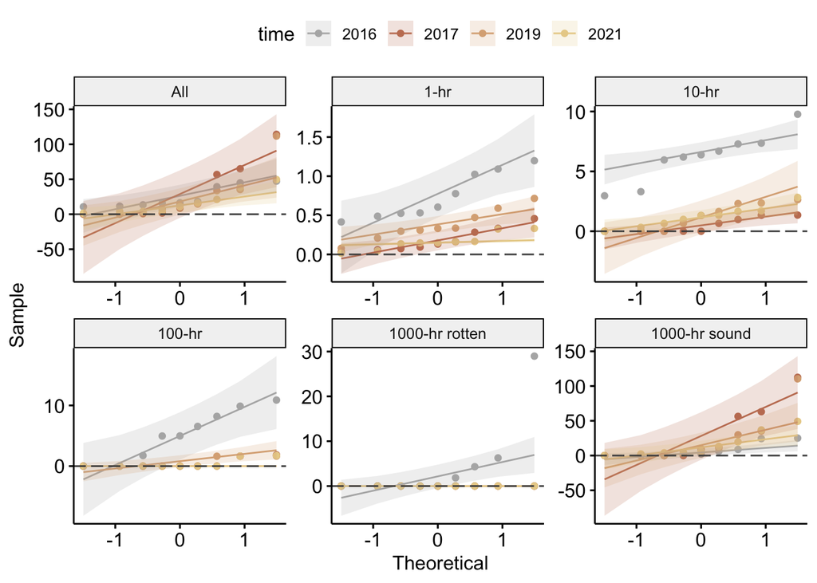

##### *Check for normality*

Plot-level values for total fuels were not normally distributed for three of the four time points (2016, 2017, 2019), as assessed by Shapiro-Wilk’s test.

The data for the 1000-hr rotten fuel class were excluded from the normality test; an abundance of zeros in this subset caused the Shapiro test to fail. However, the data for the 1000-hr rotten fuel class are shown in a QQ plot below.

Half of the fuel class year combinations were not normally distributed, as assessed by Shapiro-Wilk’s test (n = 8 of 16 combinations; hr1000r is excluded). Four combinations included the 1000-hr sound fuel class; three included year 2017.

Distribution not normal for: all 2016 all 2017 all 2019

hr0010 2017

hr0100 2017 hr0100 2019 hr0100 2021

hr1000s 2016 hr1000s 2017 hr1000s 2019 hr1000s 2021

| fuel_class | time | is_normal | p | statistic |
| --- | --- | --- | --- | --- |
| all | 2016 | FALSE | 0.0133212 | 0.784 |
| all | 2017 | FALSE | 0.0090485 | 0.769 |
| all | 2019 | FALSE | 0.0016024 | 0.705 |
| hr0010 | 2017 | FALSE | 0.0059536 | 0.754 |
| hr0100 | 2017 | FALSE | 0.0000258 | 0.552 |
| hr0100 | 2019 | FALSE | 0.0001660 | 0.620 |
| hr0100 | 2021 | FALSE | 0.0000216 | 0.545 |
| hr1000s | 2016 | FALSE | 0.0036194 | 0.735 |
| hr1000s | 2017 | FALSE | 0.0066144 | 0.757 |
| hr1000s | 2019 | FALSE | 0.0008516 | 0.681 |
| hr1000s | 2021 | FALSE | 0.0319714 | 0.817 |

#### Identify the most appropriate transformation

We applied a series of transformations to each subset, then evaluated the resulting data for outliers and normality. To create the transformed subsets, we used scale() from base R and four normalization functions from the bestNormalize package: arcsinh_x, log_x, orderNorm, and sqrt_x.

| fuel_class | time | plot_id | norm | ordnorm | si_value | sqrt | std | us_value |
| --- | --- | --- | --- | --- | --- | --- | --- | --- |
| hr0001 | 2021 | RxF08 | FALSE | FALSE | NA | NA | NA | NA |
| hr0100 | 2016 | RxF02 | FALSE | FALSE | NA | NA | NA | NA |
| hr0100 | 2016 | RxF03 | FALSE | FALSE | NA | NA | NA | NA |
| hr1000r | 2016 | RxF04 | FALSE | NA | NA | FALSE | NA | NA |
| hr1000s | 2016 | RxF06 | NA | NA | FALSE | NA | FALSE | FALSE |
| hr1000s | 2016 | RxF07 | NA | NA | FALSE | NA | FALSE | FALSE |
| hr1000s | 2021 | RxF07 | NA | NA | FALSE | NA | FALSE | FALSE |

The transformed values for CWD by fuel class were normally distributed for more of the fuel class x year combinations; but still had 5 that were not normally distributed, as assessed by Shapiro-Wilk’s test.

Total: arcsine, log, ordnorm

No tranformation resulted in normal distribution for 10-hr (2017), 100-hr (2017, 2019, 2021)

| fuel_class | time | arcsine | log | norm | ordnorm | si_value | sqrt | std | us_value |
| --- | --- | --- | --- | --- | --- | --- | --- | --- | --- |
| all | 2016 | TRUE | TRUE | TRUE | TRUE | NA | NA | NA | NA |
| all | 2017 | TRUE | TRUE | TRUE | TRUE | NA | TRUE | NA | NA |
| all | 2019 | TRUE | TRUE | TRUE | TRUE | NA | TRUE | NA | NA |
| all | 2021 | TRUE | TRUE | TRUE | TRUE | TRUE | TRUE | TRUE | TRUE |
| hr0010 | 2016 | TRUE | TRUE | TRUE | TRUE | TRUE | TRUE | TRUE | TRUE |
| hr0010 | 2019 | TRUE | NA | NA | TRUE | TRUE | NA | TRUE | TRUE |
| hr0010 | 2021 | TRUE | NA | TRUE | TRUE | TRUE | TRUE | TRUE | TRUE |
| hr0100 | 2016 | NA | NA | TRUE | TRUE | TRUE | TRUE | TRUE | TRUE |
| hr1000s | 2017 | NA | NA | TRUE | TRUE | NA | TRUE | NA | NA |
| hr1000s | 2019 | TRUE | NA | TRUE | TRUE | NA | TRUE | NA | NA |
| hr1000s | 2021 | TRUE | NA | TRUE | TRUE | NA | TRUE | NA | NA |

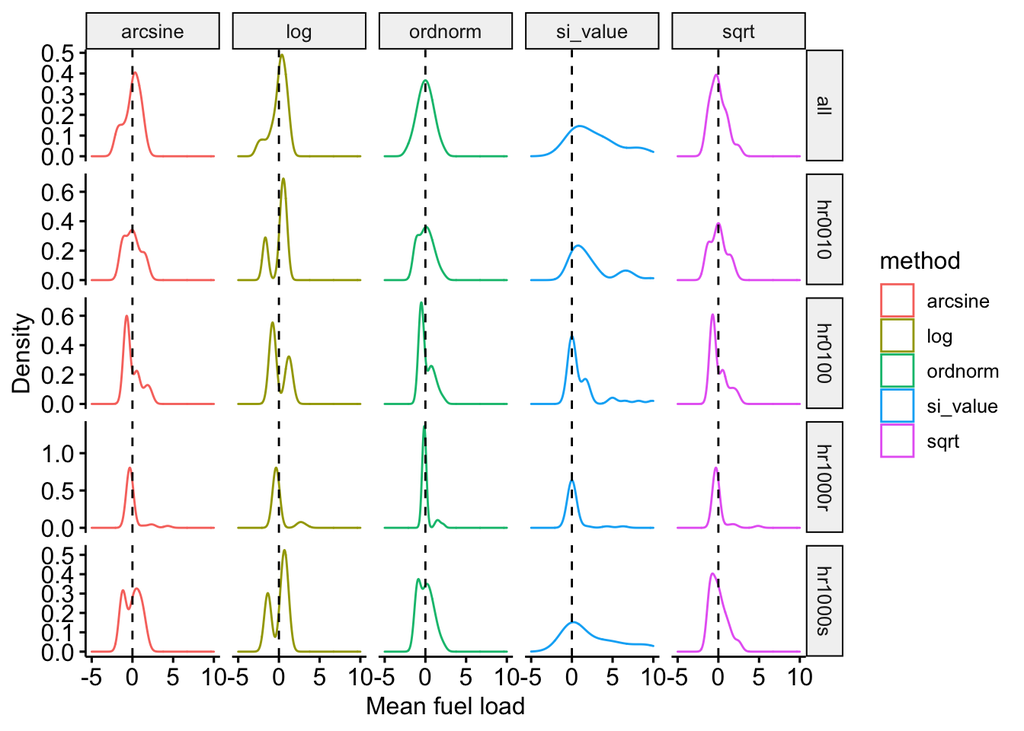

##### *Normalize and standardize data*

**SECTION IN PROGRESS**

We applied an arcsine transformation to normalize the plot-level mean values for the 1000-hr rotten fuel class, calculated as log(x + sqrt(x^2 + 1)). The arcsine transformation (also called the arcsine square root transformation, or the angular transformation) was identified as the most suitable method using the R function bestNormalize() [bestNormalize package].

We applied an ordered quantile transformation the remaining subsets (total, and mean by fuel class for the 1-hr, 10-hr, 100-hr, and 1000-hr sound classes), calculated as:

g(x) = psi^-1 * ((rank(x) - .5) / (length(x)))

All values were standardized upon normalization to have a mean of 0 and standard deviation of 1.

## Total fuel load

### Summary statistics for total fuel load by year

The following table summarizes the plot-level total amount of coarse woody debris for each time point.

| fuel_class | time | units | mean | sd | n |
| --- | --- | --- | --- | --- | --- |
| All | 2016 | MT/ha | 24.172 | 15.074 | 9 |
| All | 2017 | MT/ha | 29.139 | 40.550 | 9 |
| All | 2019 | MT/ha | 24.378 | 35.325 | 9 |
| All | 2021 | MT/ha | 16.704 | 17.012 | 9 |

### Visualization of total fuel load by year

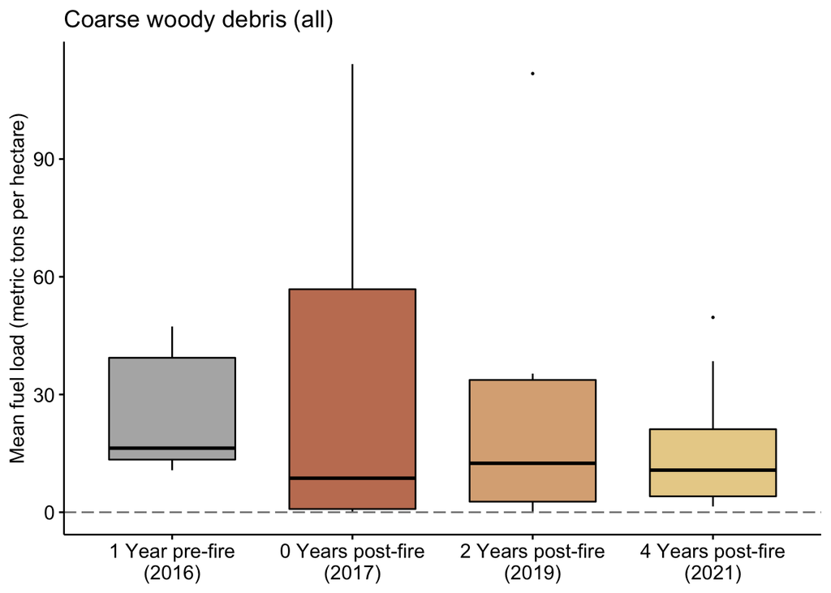

### Main effect of year on total fuel load

We conducted a one-way repeated measures ANOVA to test for a main effect of year on fuel load (i.e., whether total fuel load was significantly different between the four time points).

| fuel_class | method | effect | p_adj | p_adj_sig | statistic | d_fn | d_fd | ges | index_value |
| --- | --- | --- | --- | --- | --- | --- | --- | --- | --- |
| All | me | time | 0.435 | n.s. | 0.817 | 1.54 | 12.34 | 0.042 | value_norm |

### Pairwise comparison of total fuel load between years

| fuel_class | method | group1 | group2 | p_adj | p_adj_sig | statistic | df | index_value |
| --- | --- | --- | --- | --- | --- | --- | --- | --- |
| All | pwc | 2016 | 2017 | 1 | n.s. | 0.966 | 8 | value_norm |
| All | pwc | 2016 | 2019 | 1 | n.s. | 1.318 | 8 | value_norm |
| All | pwc | 2016 | 2021 | 1 | n.s. | 1.404 | 8 | value_norm |
| All | pwc | 2017 | 2019 | 1 | n.s. | -0.130 | 8 | value_norm |
| All | pwc | 2017 | 2021 | 1 | n.s. | -0.200 | 8 | value_norm |
| All | pwc | 2019 | 2021 | 1 | n.s. | -0.213 | 8 | value_norm |

## Mean fuel load, by fuel class

### Summary statistics for mean fuel load by fuel class and year

The following table summarizes the plot-level mean values for the five fuel classes at each time point.

| lab_class | time | units | mean | sd | n |
| --- | --- | --- | --- | --- | --- |
| 1-hr | 2016 | MT/ha | 0.739 | 0.294 | 9 |
| 1-hr | 2017 | MT/ha | 0.181 | 0.145 | 9 |
| 1-hr | 2019 | MT/ha | 0.371 | 0.194 | 9 |
| 1-hr | 2021 | MT/ha | 0.164 | 0.107 | 9 |
| 10-hr | 2016 | MT/ha | 6.212 | 2.075 | 9 |
| 10-hr | 2017 | MT/ha | 0.482 | 0.606 | 9 |
| 10-hr | 2019 | MT/ha | 1.217 | 1.087 | 9 |
| 10-hr | 2021 | MT/ha | 1.203 | 0.843 | 9 |
| 100-hr | 2016 | MT/ha | 5.245 | 4.050 | 9 |
| 100-hr | 2017 | MT/ha | 0.389 | 0.773 | 9 |
| 100-hr | 2019 | MT/ha | 0.546 | 0.819 | 9 |
| 100-hr | 2021 | MT/ha | 0.375 | 0.745 | 9 |
| 1000-hr rotten | 2016 | MT/ha | 4.600 | 9.424 | 9 |
| 1000-hr rotten | 2017 | MT/ha | 0.000 | 0.000 | 9 |
| 1000-hr rotten | 2019 | MT/ha | 0.000 | 0.000 | 9 |
| 1000-hr rotten | 2021 | MT/ha | 0.000 | 0.000 | 9 |
| 1000-hr sound | 2016 | MT/ha | 7.375 | 10.300 | 9 |
| 1000-hr sound | 2017 | MT/ha | 28.087 | 40.242 | 9 |
| 1000-hr sound | 2019 | MT/ha | 22.245 | 35.521 | 9 |
| 1000-hr sound | 2021 | MT/ha | 14.962 | 17.278 | 9 |

### Visualization of mean fuel load by fuel class and year

A box plot of coarse woody debris by year and fuel class showed the post-fire trends differed among the five coarse woody debris fuel classes. [Note: The y-axis scale in the figure below differs by fuel class]

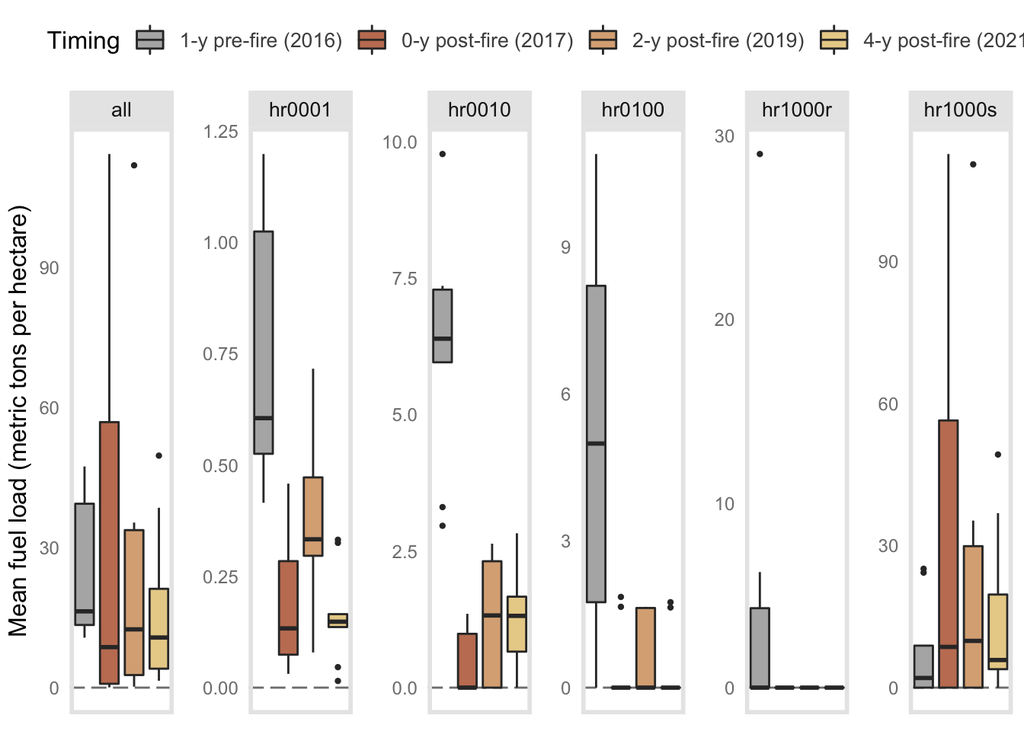

### Interaction between year and fuel class

We investigated whether there was a significant change in the plot-level fuel load over time when accounting for fuel class. A two-way repeated measures ANOVA was used to determine whether there was a significant interaction between year and fuel class on mean fuel load.

| method | effect | p_adj | p_adj_sig | statistic | d_fn | d_fd | ges | index_value |
| --- | --- | --- | --- | --- | --- | --- | --- | --- |
| interaction | time:fuel_class | 6.99e-05 | *** | 4.248 | 12 | 96 | 0.217 | value_norm |

#### Effect of treatment on each fuel class

| fuel_class | method | effect | p_adj | p_adj_sig | statistic | d_fn | d_fd | ges | index_value |
| --- | --- | --- | --- | --- | --- | --- | --- | --- | --- |
| hr0010 | me | time | 3.80e-06 | *** | 20.714 | 3.00 | 24.00 | 0.675 | value_norm |
| hr0001 | me | time | 2.43e-05 | *** | 16.532 | 3.00 | 24.00 | 0.578 | value_norm |
| hr0100 | me | time | 5.00e-03 | ** | 7.495 | 3.00 | 24.00 | 0.418 | value_norm |
| hr1000r | me | time | 8.00e-02 | n.s. | 4.193 | 3.00 | 24.00 | 0.282 | value_norm |
| hr1000s | me | time | 1.00e+00 | n.s. | 0.864 | 1.58 | 12.64 | 0.048 | value_norm |

### Pairwise comparisons of mean fuel load between years, by fuel class

fuel_class

method

group1

group2

p_adj

p_adj_sig

statistic

df

index_value

hr0001

pwc

2017

2019

0.003000

-5.749

8

value_norm

hr0001

pwc

2016

2021

0.005000

5.130

8

value_norm

hr0001

pwc

2016

2017

0.008000

4.790

8

value_norm

hr0001

pwc

2019

2021

0.026000

3.931

8

value_norm

hr0010

pwc

2016

2017

0.000572

***

7.168

8

value_norm

hr0010

pwc

2016

2021

0.001000

***

6.423

8

value_norm

hr0010

pwc

2016

2019

0.008000

4.772

8

value_norm

hr0100

pwc

2016

2021

0.047000

3.526

8

value_norm

**1-hour**

A post hoc pairwise comparison showed a significant difference in 1-hr fuel load between 2016-2017, 2016-2021, and 2017-2019 (p < 0.01); as well as 2019-2021 (p < 0.05). No other comparisons were significant.

**10-hour**

A post hoc pairwise comparison showed a significant difference in 10-hr fuel load between 2016-2017 (p < 0.001), 2016-2021 (p < 0.01), and 2016-2019 (p < 0.05). No other comparisons were significant.

**100-hour**

**1000-hour rotten**

Post hoc comparisons showed no significant difference in 1000-hr rotten fuel load between years at a significance level of < 0.05.

**1000-hour sound**

Post hoc comparisons showed no significant difference in 1000-hr sound fuel load between years at a significance level of < 0.05.